# TÉCNICA GRUPO I (Básicas y populares): Pyramid Charts

https://telencuestas.com/censos-de-poblacion/chile/2024/libertador-general-bernardo-ohiggins

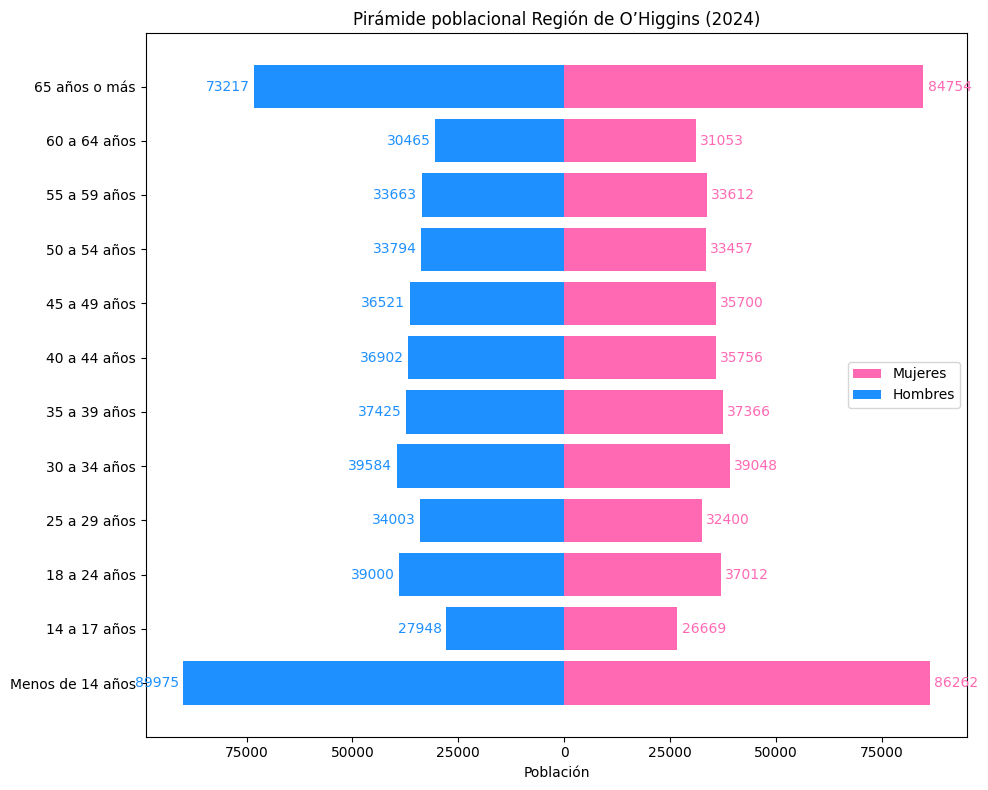

# TÉCNICA GRUPO II (Habituales y específicas): Voronoy diagram

Los datos corresponden a la distribución territorial de defunciones fetales por comuna en Chile durante el año 2002, utilizando las columnas Latitud, Longitud y REG_RES (Región de residencia). Cada punto se ubica según las coordenadas geográficas de la comuna correspondiente, y su tamaño es proporcional al número de casos registrados en esa zona. Esta visualización permite identificar espacialmente las comunas con mayor incidencia de defunciones fetales. Los datos fueron obtenidos del Ministerio de Salud de Chile (MINSAL), a partir de registros abiertos de defunciones fetales por región y comuna.

```
Año con menos casos: 2002
```

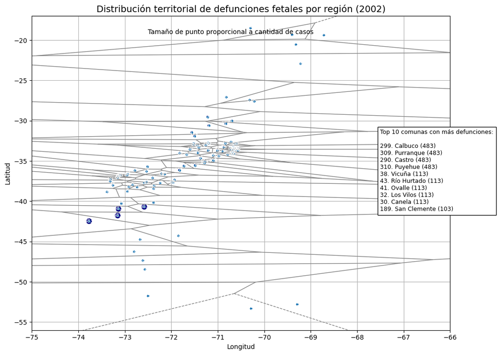

# TÉCNICA GRUPO III (Menos habituales o específicas): Bullet Graphs

La mortalidad materna se refiere a las muertes debidas a complicaciones del embarazo o el parto. De 2000 a 2023, la tasa mundial de mortalidad materna (MMR) disminuyó en un 40 por ciento, de 328 muertes a 197 muertes por cada 100.000 nacidos vivos, según estimaciones interinstitucionales de la ONU. Esto se traduce en una tasa media anual de reducción del 2,2%. Si bien es sustantivo, lograr el Objetivo de Desarrollo Sostenible (ODS) de 70 muertes maternas por cada 100.000 nacidos vivos para 2030 requerirá una tasa anual de reducción de casi el 15% durante los próximos 7 años (2024-2030).

https://data.unicef.org/topic/maternal-health/maternal-mortality/#data

[figure not shown]

[output not shown]

[output not shown]